# Group Project

[anonymous authors]

Fall 2018

1.0

## Research Question

Does a history of a head injury increase a person’s likelihood of having a psychological or emotional condition severe enough to require medication?

## Why were we interested in this question?

We were interested in investigating this research question because we have group members who have had head injuries in the past, so we were interested in the long term consequences of those injuries. We have also noticed an increase in concern regarding psychological and emotional problems, so we were interested in investigating possible causes of mental and emotional problems. Finally, we have noticed that many kids are participating in activities such as sports that often lead to head injuries, and we were interested in the possible consequences of these activities on the overall mental and emotional well being of those kids.

## Where did we get our data?

Our data came from the HELPfull data set in the mosaic library. This data set consisted of data acquired from many questions asked by primary care physicians to patients in an inpatient detoxification program in Boston. Two of the questions asked were whether or not the patient had a history of a head injury and whether or not they had ever been medicated for psychological or emotional problems were two of these questions. The fact that our samples came from an inpatient detoxification unit raised some concerns that the patients in our samples are not representative of all people who have been medicated for psychological or emotional problems or who have had psychological or emotional problems severe enough to warrant medication because they require inpatient detoxification treatment, so we applied our conclusions very cautiously to anyone outside of people who have required detoxification treatment.

## What were our variables? What did they measure?

From our data, we had two categorical variables. The first variable was whether or not a patient had a history of a head injury (yes or no). This variable was in the data set as C2W1. The other variable was whether or not the patient had ever been medicated for a psychological or emotional issue (yes or no). This was in the data set as G1D. From these variables, we compared the proportion of patients with a history of a head injury who had been medicated for a psychological or emotional problem and the proportion of patients with no history of a head injury who had been medicated for a psychological or emotional problem.

## Load packages

```r
library(mosaic)
library(broom)
```

##### Exploratory data analysis

###### Use data documentation (help files, code books, Google, etc.), the `str` command, and other summary functions to understand the data.

```r
HELPfull_select <- select(HELPfull, C2W1, G1D)
HELPfull_select
```

| C2W1 | G1D |
| --- | --- |
| 0 | 1 |
| NA | 1 |
| NA | 0 |
| NA | 0 |
| 1 | 0 |
| NA | 0 |
| 0 | 0 |
| NA | 0 |
| NA | 0 |
| 0 | 0 |

[output cut: 990 more lines]

###### Prepare the data for analysis. [Not always necessary.]

```r
filter(HELPfull, !is.na(G1D)) %>% filter(!is.na(C2W1)) %>% select(G1D, C2W1)->new_data
```

```r
injury <- factor(new_data$C2W1, levels = c(1, 0), labels = c("yes", "no"))
```

```r
meds <- factor(new_data$G1D, levels = c(1,0), labels = c("yes", "no"))
```

```r
meds_injury <- data.frame(meds, injury)
```

```r
meds_injury
```

| meds | injury |
| --- | --- |
| yes | no |
| no | yes |
| no | no |
| no | no |
| no | yes |
| no | no |
| yes | no |
| no | yes |
| yes | yes |
| no | no |

[output cut: 460 more lines]

###### Make tables or plots to explore the data visually.

```r
str(meds_injury)
```

```
'data.frame':   470 obs. of  2 variables:
 $ meds  : Factor w/ 2 levels "yes","no": 1 2 2 2 2 2 1 2 1 2 ...
 $ injury: Factor w/ 2 levels "yes","no": 2 1 2 2 1 2 2 1 1 2 ...
```

```r
tally(meds ~ injury, data = meds_injury, margins = TRUE)
```

```
       injury
meds    yes  no
  yes    68  52
  no    137 213
  Total 205 265
```

```r
tally(meds ~ injury, data = meds_injury, margins = TRUE, format = "percent")
```

```
       injury
meds          yes        no
  yes    33.17073  19.62264
  no     66.82927  80.37736
  Total 100.00000 100.00000
```

##### Hypotheses

###### Identify the sample (or samples) and a reasonable population (or populations) of interest.

We are working with two samples here. One sample is made up of 205 patients from an inpatient detoxification unit in Boston participating in a clinical trial who have a history of a head injury. The other sample is made up of 265 patients in that same inpatient treatment center who do not have a history of a head injury. The people in this sample are special in that they are in an inpatient detoxification treatment program. As such, we can only really generalize our results to people who have required detoxification, so our population is all people in detox who have and have not had a head injury (so everyone in detox programs).

###### Express the null and alternative hypotheses as contextually meaningful full sentences.

$H_{0}:$ There is no difference in the proportion of people who have a history of head injury who have been medicated for a psychological or emotional problem and the proportion of people who have not had a history of head injury who have been medicated for a psychological or emotional problem.

$H_{A}:$ There is a difference in the proportion of people who have a history of head injury who have been medicated for a psychological or emotional problem and the proportion of people who have not had a history of head injury who have been medicated for a psychological or emotional problem.

###### Express the null and alternative hypotheses in symbols (when possible).

$H_{0}: p_{yes-injury} - p_{no-injury} = 0$

$H_{A}: p_{yes-injury} - p_{no-injury} \neq 0$

##### Model

###### Identify the sampling distribution model.

We will use a normal model.

###### Check the relevant conditions to ensure that model assumptions are met.

- Random
  - Our sample came from patients in a detoxification program in Boston, so the patients in the sample were not randomly selected from different areas. As such, the patients in detox in Boston may be different from all patients in detox, so we will apply our conclusions with caution. We hope, though, that the patients in this sample are representative of all patients in detox in the world.
- 10%
  - There are certainly more than 4700 people who have ever required detoxification treatment, so our sample of 470 people in detox with and without a history of a head injury is less than 10% of the population of interest.
- Success/Failure
  - The contingency table above shows that there are 68 people who have been medicated for psychological and emotional issues and have had a head injury, and there are 52 people who have been medicated for psychological and emotional issues and have not had a head injury (successes). Furthermore, there are 137 people who have not been medicated for a psychological and emotional issue who have had a head injury, and there are 213 people who have not been medicated for a psychological and emotional issue who have not had a head injury (failures). As all of these numbers are larger than 10, the success/failure condition is met.

##### Mechanics

###### Compute and report the test statistic.

```r
meds_injury_test <- prop.test(meds ~ injury, data = meds_injury)
meds_injury_test_tidy <- tidy(meds_injury_test)
meds_injury_test_tidy
```

| estimate1 | estimate2 | statistic | p.value | parameter | conf.low | conf.high | method | alternative |
| --- | --- | --- | --- | --- | --- | --- | --- | --- |
| 0.3317073 | 0.1962264 | 10.45728 | 0.001221673 | 1 | 0.05090348 | 0.2200583 | 2-sample test for equality of proportions with continuity correction | two.sided |

The test statistic is 0.1354809.

To compute the Z-score:

```r
SE <- sqrt(meds_injury_test_tidy$estimate1 *
               (1 - meds_injury_test_tidy$estimate1)/205 +
           meds_injury_test_tidy$estimate2 *
               (1 - meds_injury_test_tidy$estimate2)/265)
SE
```

```
[1] 0.04094545
```

```r
Z <- (meds_injury_test_tidy$estimate1 - meds_injury_test_tidy$estimate2)/SE
Z
```

```
[1] 3.308815
```

The z-score is 3.3088146.

###### Plot the null distribution.

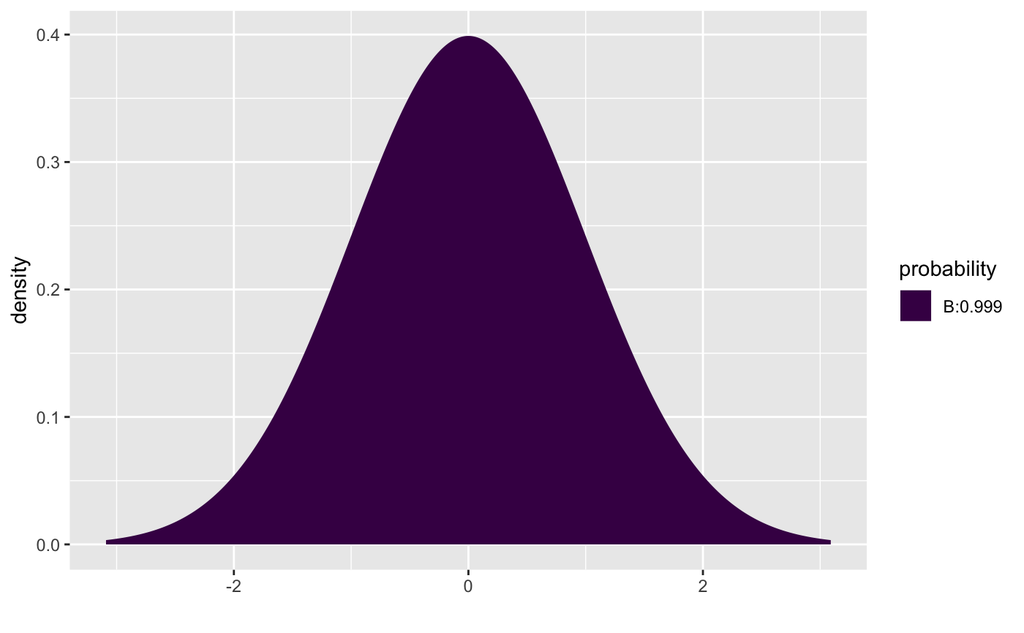

```r
pdist("norm", q = c(-Z, Z), invisible = TRUE)
```

###### Calculate and interpret the P-value.

```r
P <- 2 * pdist("norm", q = -Z, plot = FALSE)
P
```

```
[1] 0.0009369187
```

The P-value is 0.0009369. If there were truly no difference in the proportion of people who have a history of head injury who have been medicated for a psychological or emotional problem and the proportion of people who have not had a history of head injury who have been medicated for a psychological or emotional problem, there is a 0.0936919% chance of seeing a difference in our data at least as extreme as what we saw.

##### Conclusion

###### State the statistical conclusion.

We reject the null hypothesis.

###### State (but do not overstate) a contextually meaningful conclusion.

We have sufficient evidence to suggest that there is a difference in the proportion of people who have a history of head injury who have been medicated for a psychological or emotional problem and the proportion of people who do not had a history of head injury who have been medicated for a psychological or emotional problem.

###### Identify the possibility of either a Type I or Type II error and state what making such an error means in the context of the hypotheses.

As we rejected the null hypothesis, we run the risk of committing a Type I error. This would mean that we concluded there is a difference in the proportion of people who have a history of head injury who have been medicated for a psychological or emotional problem and the proportion of people who do not had a history of head injury who have been medicated for a psychological or emotional problem when, in fact, there is not a difference.

##### Confidence interval

###### Check the relevant conditions to ensure that model assumptions are met.

The conditions have been checked above.

###### Calculate the confidence interval.

```r
meds_injury_test_tidy$conf.low
```

```
[1] 0.05090348
```

```r
meds_injury_test_tidy$conf.high
```

```
[1] 0.2200583
```

###### State (but do not overstate) a contextually meaningful interpretation.

We are 95% confident that the true difference between the proportion of people who have a history of head injury who have been medicated for a psychological or emotional problem and the proportion of people who do not had a history of head injury who have been medicated for a psychological or emotional problem is captured in the interval (0.0509035, 0.2200583). (This difference is measured by calculating yes history of head injury minus no history of head injury.)

###### If running a two-sided test, explain how the confidence interval reinforces the conclusion of the hypothesis test.

The confidence interval does not contain the null value of zero. If zero is not a realistic value for the true difference between the proportion of people who have a history of head injury who have been medicated for a psychological or emotional problem and the proportion of people who do not had a history of head injury who have been medicated for a psychological or emotional problem, then it makes sense that we rejected the null hypothesis that stated this difference would be zero.

## What does our conclusion mean in real life? Why is this important?

The data and conclusion suggest that having a previous history of head injuries has some correlation with having emotional and psychological issues severe enough to require medication (at least for patients who require detoxification treatment). In light of these findings, we can be more aware of the emotional and psychological health of individuals who have a history of a head injury since we know there is, in fact, a statistical relationship between head injuries and emotional/psychological problems (again, at least for patients in detox). We can also be proactive in preventing head injuries through activities such as high contact sports, knowing those injuries may lead to emotional/psychological problems.

## Who may be interested in our results? What would they do with these results?

Most importantly, staff at detoxification units could benefit from the findings of our research. Substance abuse and emotional/psychological issues have been linked in past research, so knowing which patients have had a head injury may change their treatment approach if they are aware that those patients may be more likely to suffer from mental and emotional problems. We can also cautiously apply our conclusions outside of detoxification patients, knowing that the general population and detox patients may be different in some ways. In doing so, we may find that parents might be interested in our results. Many sports subject kids to head injuries, so knowing that those potential injuries may increase their child’s risk for a psychological or emotional condition severe enough to require medication may influence their decisions regarding what sports to allow their kids to play. Furthermore, doctors may be interested in our results. Since there may be an increased risk of a psychological or emotional condition severe enough to require medication in people who have had a head injury in the general public, doctors may want monitor their patients who have experienced head injuries more closely for psychological and emotional health post-injury. Finally, those concerned with public health matters may find our results important. As our results indicate that avoiding head injuries may lower one’s risk for developing a psychological or emotional condition severe enough to require medication, encouraging people to avoid activities in which they may obtain a head injury can help prevent these psychological or emotional conditions severe enough to require medication, thereby decreasing the overall instances of those problems.

## Reflection

This project was incredibly interesting, as it showed that head injuries and psychological and emotional problems are correlated, at least for patients in detoxification programs. As psychological and emotional problems have incredible impacts on the lives of people who suffer from them, it was fun to be part of a process identifying causes of those problems, as this knowledge could lead to prevention of those problems. Through this process, we learned how difficult it can be to find data from which interesting and relevant conclusions can be drawn but that is also plentiful enough for hypothesis testing. If we were to do this project again, we would look for data related to our research question that did not come from as limited of a group as patients in detox. Because all our data in this project did come from just patients in detox, we were limited in how broadly we could apply our conclusions. After completing this project, we see how variables we could encounter in everyday life, such as a history of head injury and psychological or emotional health, could be correlated. As such, we think we will notice possible correlations more often. Furthermore, after going through the process of testing one such correlation, we see how strict the conditions under which we can claim a correlation are. As such, we may be more skeptical of other statistical claims we encounter without knowing they went through the proper statistical process to reach their conclusion. Finally and possibly most obviously, we will try to avoid head injuries, knowing they could have an impact on our emotional or psychological health.